# DSCI351-351m-451: Class 01a, (CWRU, Pitt, UCF, UTRGV)

Profs: R. H. French, L. S. Bruckman, P. Leu, K. Davis, S. Cirlos

TAs: W. Oltjen, K. Hernandez, M. Li, M. Li, D. Colvin

01 November, 2022

#### Textbooks

- [Peng: R Programming for Data Science](https://leanpub.com/rprogramming)
- [Peng: Exploratory Data Analysis with R](https://leanpub.com/exdata)
- [Open Intro Stats, v4](https://openintro.org/os)
- [Wickham: R for Data Science](https://r4ds.had.co.nz/)
- [Hastie: Intro to Statistical Learning with R, 2nd Ed.](https://www.statlearning.com/)

Introduction to R and Data Science

- For R, Coding, Inferential Statistics
  - Peng: R Programming for Data Science
  - Peng: Exploratory Data Analysis with R

Textbooks for this class

- OIS = Diez, Barr, Çetinkaya-Runde: Open Intro Stat v4
- R4DS = Wickham, Grolemund: R for Data Science

Textbooks for DSCI353/353M/453, And in your Repo now

- ISLR2 = James, Witten, Hastie, Tibshirani: Intro to Statistical Learning with R 2nd Ed.
- ESL = Trevor Hastie, Tibshirani, Friedman: Elements of Statistical Learning
- DLwR = Chollet, Allaire: Deep Learning with R

Magazine Articles about Deep Learning

- DL1 to DL13 are “Deep Learning” articles in 3-readings/2-articles/

#### Syllabus

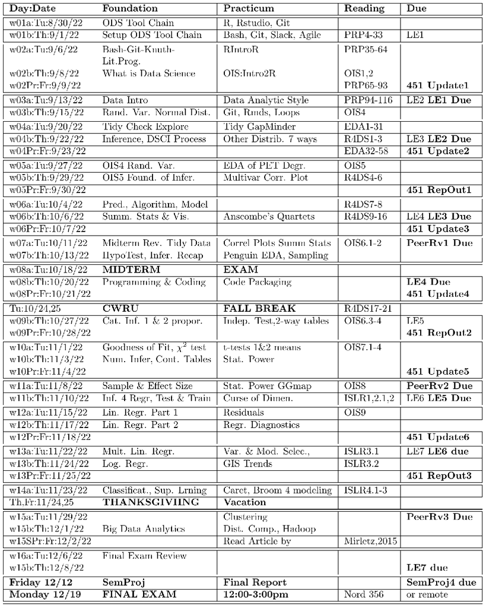

DSCI351-351M-451 Syllabus

#### For the DSCI 451 students they have an EDA SemProj to do

##### Care should be taken when choosing SemProj datasets.

- Report Out 1 focuses on
  - Explaining the ‘why’ of your research project
  - Describing your dataset
  - Presenting an analysis plan
  - Cleaning your data
- Report Out 2 focuses on:
  - EDA of your data
  - Visualizing your data
  - Further cleaning of your data
  - Reevaluation of your data analysis plan (Do you need more data?)
- Report Out 3:
  - More data visualization
  - Initial modeling
  - Conclusions about your data
  - Were you able to answer your why question?
  - What else would you need to do to get to understanding your data better?

#### Tidyverse Cheatsheets, Functions and Reading Your Code

- Look at the Tidyverse Cheatsheet
  - **Tidyverse For Beginners Cheatsheet**
    - In the Git/20s-dsci353-353m-453-prof/3-readings/3-CheatSheets/ folder
  - **Data Wrangling with dplyr and tidyr Cheatsheet**

  Tidyverse Functions & Conventions
  - The pipe operator `%>%`
  - Use `dplyr::filter()` to subset data row-wise.
  - Use `dplyr::arrange()` to sort the observations in a data frame
  - Use `dplyr::mutate()` to update or create new columns of a data frame
  - Use `dplyr::summarize()` to turn many observations into a single data point
  - Use `dplyr::arrange()` to change the ordering of the rows of a data frame
  - Use `dplyr::select()` to choose variables from a tibble,
    - keeps only variables you mention
  - Use `dplyr::rename()` keeps all the variables and renames variables
    - rename(iris, petal_length = Petal.Length)
  - These can be combined using `dplyr::group_by()`
    - which lets you perform operations “by group”.
  - The `%in%` matches conditions provided by a vector using the c() function
  - The **forcats** package has tidyverse functions
    - for factors (categorical variables)
  - The **readr** package has tidyverse functions
    - to read_…, melt_… col_…, parse_… data and objects

Reading Your Code: Whenever you see

- The assignment operator `<-`, think **“gets”**
- The pipe operator, `%>%`, think **“then”**

#### Links